# Unit 10 Exploratory Data

James Vasquez

July 6, 2018

## Mental Health

1. Mental Health Clinics
   1. Download the RDA and set to Global Environment
   2. List the unique state codes from the ‘LST’ column
   3. Filter the data set to show only Mainland states and the count of VA’s centers in each states
   4. Create a bar chart of the filtered data
      1. Label the axis
      2. Title should be centered
      3. Legend is optional

```r
library(sqldf)
```

```r
library(ggplot2)

##############################################
#####                          ###############
#####                          ###############
#####    Make State DB         ###############
#####                          ###############
##############################################

#Create State DB data frame
StateDB <- data.frame(state.name, state.abb, state.area, state.region)
colnames(StateDB)[colnames(StateDB)=='state.name'] <- 'StateName'
colnames(StateDB)[colnames(StateDB)=='state.abb'] <- 'StateAbrev'
colnames(StateDB)[colnames(StateDB)=='state.area'] <- 'StateSize_mi2' #Data is in Square miles
colnames(StateDB)[colnames(StateDB)=='state.region'] <- 'StateRegion'

#Add district of Columbia to StateDB Data Frame
DistrictColumbia <- data.frame("District of Columbia","DC", "68.34", "South")
names(DistrictColumbia) <- c("StateName","StateAbrev", "StateSize_mi2", "StateRegion")
StateDB <- rbind(StateDB, DistrictColumbia)

#Read the data set
load(file = "N-MHSS-2015-DS0001-data-r.rda")

#Trim Function to remove leading and trailing white spacing
trim <- function (x) gsub("^\\s+|\\s+$", "", x)
mh2015_puf$LST <- trim(mh2015_puf$LST)

#######################################################
####
####   B. list unique state names from column LST
####
#######################################################

#List unique state abbrevations order by State Abrev.
#Showing only first 6 rows
sqldf("Select distinct LST
      FROM mh2015_puf
      order by 1")
```

```
##    LST
## 1   AK
## 2   AL
## 3   AR
## 4   AS
## 5   AZ
## 6   CA
## 7   CO
## 8   CT
## 9   DC
## 10  DE
## 11  FL
## 12  GA
## 13  GU
## 14  HI
```

[output cut: 41 more lines]

```r
#######################################################
####
####   C. Filter data to only rows that are Mainland
####
#######################################################

#adding a mainland vs non-mainland column
mh2015_puf <- sqldf("SELECT *,
      case
        when LST = 'AK' then 'NonMainland'
        when LST = 'PR' then 'NonMainland'
        when LST = 'HI' then 'NonMainland'
        when LST = 'AS' then 'NonMainland'
        when LST = 'FM' then 'NonMainland'
        when LST = 'GU' then 'NonMainland'
        when LST = 'MH' then 'NonMainland'
        when LST = 'MP' then 'NonMainland'
        when LST = 'PW' then 'NonMainland'
        when LST = 'VI' then 'NonMainland'
        when LST = 'AE' then 'NonMainland'
        when LST = 'AA' then 'NonMainland'
        when LST = 'AP' then 'NonMainland'
        else 'Mainland'
        END AS 'StateType'
      FROM mh2015_puf")

#count of medical centers by state
mh2015_puf_Mainland <- sqldf("select LST as StateAbrev, count(*) as CountOfCenters
                                  from mh2015_puf
                                  WHERE StateType = 'Mainland'
                                  group by LST
                                  Order by 2 desc")

#Add full State Name
mh2015_puf_Mainland <- merge(mh2015_puf_Mainland, StateDB, by=("StateAbrev"))

#Show top 6 rows
head(mh2015_puf_Mainland)
```

```
##   StateAbrev CountOfCenters   StateName StateSize_mi2 StateRegion
## 1         AL            197     Alabama         51609       South
## 2         AR            259    Arkansas         53104       South
## 3         AZ            386     Arizona        113909        West
## 4         CA            913  California        158693        West
## 5         CO            203    Colorado        104247        West
## 6         CT            241 Connecticut          5009   Northeast
```

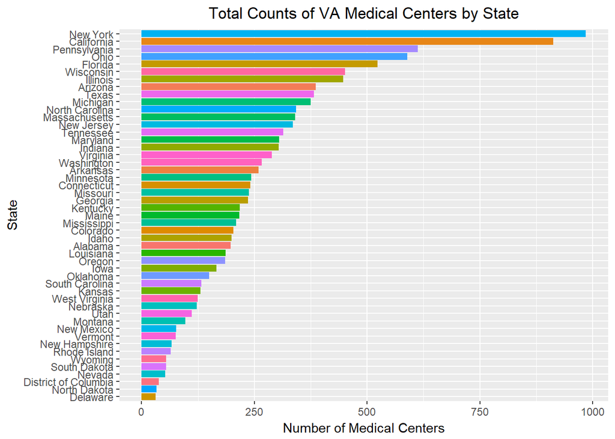

```r
#######################################################
####
####   1D. Create bar chart
####
#######################################################

#Create bar plot of total medical centers by state
ggplot(data=mh2015_puf_Mainland,
       aes(x=reorder(StateName, CountOfCenters), #order the bars by value
           y=CountOfCenters,
           fill=StateName)) +  #color the bars by state name
      geom_bar(stat="identity")+
      theme(legend.position="none",   #Remove the legend
            plot.title=element_text(hjust=0.5)) +  #center the title
      coord_flip()+
      labs(x="State",
           y="Number of Medical Centers",
           title = "Total Counts of VA Medical Centers by State")
```

## Tidying Data and Merging Data

2. Cleaning and Bringing in New Features
   1. Add the state.area and state.region data sets in R to previous dataframe
      1. Refer to the StateDB merge
      2. In order for ther merge to work, it was necessary to remove leading and trailing spaces in the LST column (see trim function).
   2. Tidy the LST data column and merge the to the filtered data sets
      1. Refer to the StateDB and trim function
      2. Removed the leading and trailing spaces from the LST column
   3. Calculate VA hospitals per 1K square miles
      1. VA_CenterDensity = CountOfCenters/(StateSize_mi2/1000.0)
   4. Create a bar chart of the filtered data with new features
      1. Label the axis
      2. Bars should be in descending order
      3. Color code data on Region
      4. Add legend
   5. What patterns do you see
      1. Any region that seems relatively high for VA med centers/ 1K mi^2 *(South)*
      2. How about low *(West)*
      3. What advice might you give your boss before modeling starts *(remove the outlier)*

```r
#######################################################
####
####   1C. Calculate new variable hospitals per 1K square miles
####
#######################################################

mh2015_puf_Mainland <- sqldf("SELECT *,
                                  CountOfCenters/(StateSize_mi2/1000.0) as VA_CenterDensity
                                  FROM mh2015_puf_Mainland")
head(mh2015_puf_Mainland,3)
```

```
##   StateAbrev CountOfCenters StateName StateSize_mi2 StateRegion
## 1         AL            197   Alabama         51609       South
## 2         AR            259  Arkansas         53104       South
## 3         AZ            386   Arizona        113909        West
##   VA_CenterDensity
## 1         3.817164
## 2         4.877222
## 3         3.388670
```

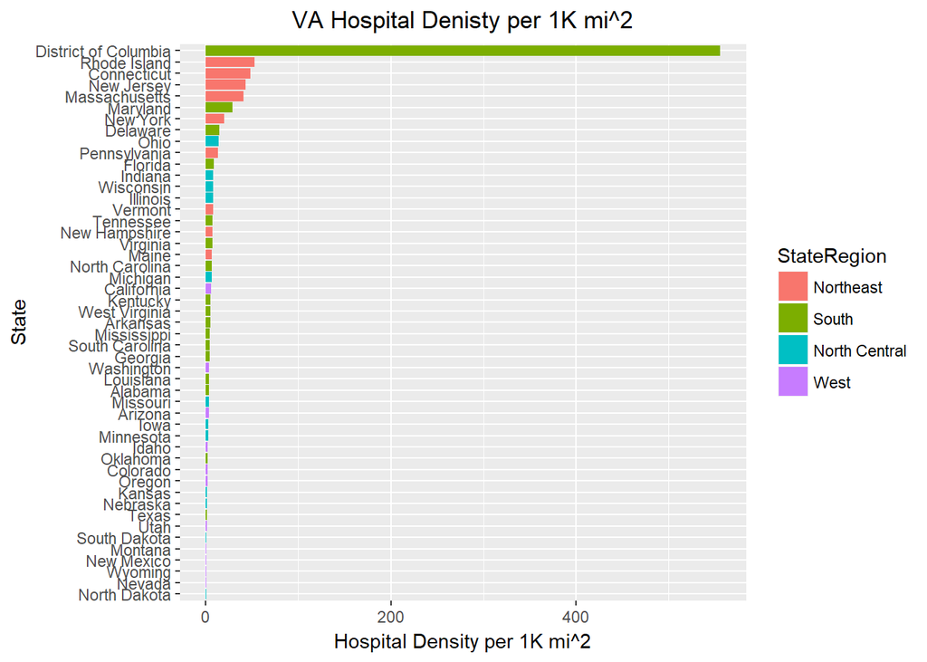

```r
#Create bar plot of total medical centers by state
ggplot(data=mh2015_puf_Mainland,
       aes(x=reorder(StateName, VA_CenterDensity), #order the bars by value
           y=VA_CenterDensity,
           fill=StateRegion)) +  #color the bars by state name
  geom_bar(stat="identity")+
  theme(plot.title=element_text(hjust=0.5)) +  #center the title
  coord_flip()+
  labs(x="State",
       y="Hospital Density per 1K mi^2",
       title = "VA Hospital Denisty per 1K mi^2")
```

## Removing the outlier - DC

After seeing the plot above the DC entry is weighing the graph too much for analysis. In the below chart the DC entry has been removed to better see the results.

2. What patterns do you see
   1. Any region that seems relatively high for VA med centers/ 1K mi^2
      1. The NorthEast region four states with the highest density of VA hospitals. Rhode Island, Connecitcut, New Jersey, and Massachusetts
   2. How about low
      1. West and NorthCentral states have low VA hospital density. This is likely because the states are much larger but have fewer VA hospitals due to the fact that they are in the larger cities.
   3. What advice might you give your boss before modeling starts
      1. For better results we may want to find additional ways to group the states
      2. For an additional group we could group the states by population and area of the states, this would allow for comparison on an equal basis.

*District of Columbia (DC) is not a state but rather just a small slice of Maryland*

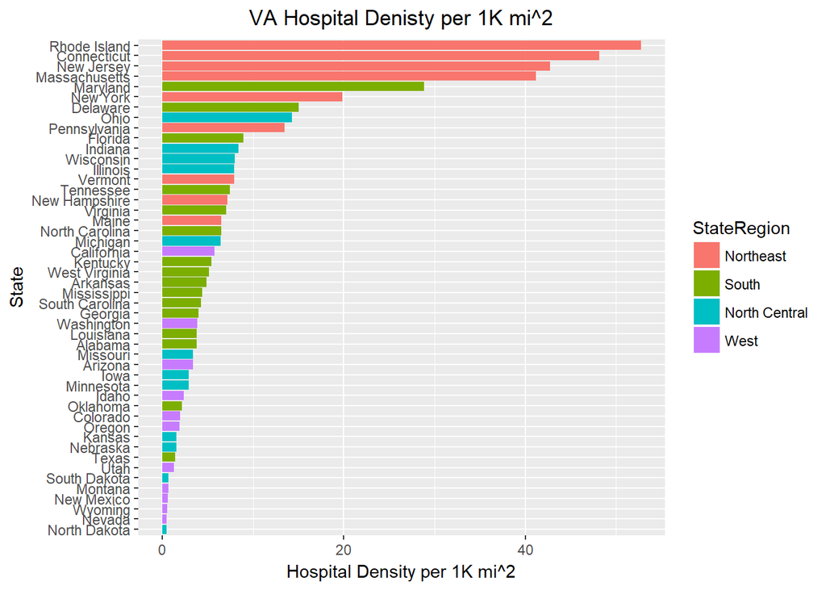

```r
#Removing DC from the DataSet
mh2015_puf_Mainland_NoDC <- mh2015_puf_Mainland[!(mh2015_puf_Mainland$StateAbrev=="DC"),]

#Plotting the data without DC
ggplot(data=mh2015_puf_Mainland_NoDC,
       aes(x=reorder(StateName, VA_CenterDensity), #order the bars by value
           y=VA_CenterDensity,
           fill=StateRegion)) +  #color the bars by state name
  geom_bar(stat="identity")+
  theme(plot.title=element_text(hjust=0.5)) +  #center the title
  coord_flip()+
  labs(x="State",
       y="Hospital Density per 1K mi^2",
       title = "VA Hospital Denisty per 1K mi^2")
```